# Probability Base

Alene Onion

08 October, 2024

# Probability analysis

## Load packages

```r
library(tidyverse)
library(huxtable)
library(ggplot2)
library(lubridate)
library(spsurvey) #This code was written for spsurvey v5.0.0
```

## Load data

To run cat_analysis(), the dataframe will need to include columns for the categorical variable you are interested in, weight for each site, xcoordinate and ycoordinate. Optionally, you can also include a subpopulation or stratum column to separate results and site IDs for two-stage analysis (for example, if there are repeated sites).

In this script, weight is adjusted because of the proportional design. In the future, this can be excluded as the design should include weights already.

I am designating relevant variables from the dataset as well as creating new variables: mean dissolved oxygen from 0-2m, epilimentic means for ph and spconductance, total nitrogen and DIN:TP ratio.

pulling in WQS comparisons

```
## [1] "removing these parameters because there are fewer than 30 sites sampled: ,magnesium(total)"
## [2] "removing these parameters because there are fewer than 30 sites sampled: ,nitrate(total)"
## [3] "removing these parameters because there are fewer than 30 sites sampled: ,nitrite(total)"
## [4] "removing these parameters because there are fewer than 30 sites sampled: ,total_dissolved_nitrogen(dissolved)"
## [5] "removing these parameters because there are fewer than 30 sites sampled: ,turbidity"
## [6] "removing these parameters because there are fewer than 30 sites sampled: ,uv_254(total)"
```

Additionally, I will load in NLA, NAP and NH data:

```r
################################################################################################################
#Ended here

# read in NLA data
chem <- read.csv("nla_2017_water_chemistry_chla-data.csv")

chem <- chem %>%
  filter(ANALYTE %in% c("NTL","CHLA","PTL","NITRATE_N","COLOR","CHLORIDE"),
         NARS_FLAG == "") %>%
  select(UID,SITE_ID,DATE_COL,ANALYTE,RESULT) %>%
  pivot_wider(names_from= ANALYTE ,values_from = RESULT,) %>%
  rename(TN=NTL,TP=PTL)

oxygen <- read.csv("nla_2017_profile-data.csv")

oxygen <- oxygen %>%
  select(UID,SITE_ID,DATE_COL,DEPTH,OXYGEN) %>%
  # dissolved oxygen:
  # keep DO values between 0 and 2m depth
  mutate(keep=case_when(
    DEPTH <= 2 ~ "yes",
    DEPTH > 2 ~ "no")) %>%
  filter(keep=="yes") %>%
  select(-keep)

# mean DO for each lake
DO <- aggregate(oxygen$OXYGEN,list(oxygen$SITE_ID,oxygen$DATE_COL),FUN=mean)
# add back in
oxygen <- merge(oxygen,DO,by.x=c("SITE_ID","DATE_COL"),by.y=c("Group.1","Group.2"),all.x=TRUE)
oxygen$x <- as.numeric(oxygen$x)
oxygen <- oxygen %>%
  select(-c(DEPTH,OXYGEN)) %>%
  rename(OXYGEN=x) %>%
  distinct()

att.nla <- merge(chem,oxygen,by=c("UID","SITE_ID","DATE_COL"),all.y=TRUE,all.x=TRUE)
att.nla$CHLA <- as.numeric(att.nla$CHLA)
att.nla$TN <- as.numeric(att.nla$TN)
att.nla$TP <- as.numeric(att.nla$TP)
att.nla$CHLORIDE <- as.numeric(att.nla$CHLORIDE)
att.nla$OXYGEN <- as.numeric(att.nla$OXYGEN)
att.nla$COLOR <- as.numeric(att.nla$COLOR)
att.nla$DINTP <- as.numeric(att.nla$NITRATE_N)/(as.numeric(att.nla$TP)/1000)

# selecting parameters and adding trophic status

att.nla<-att.nla %>%
  # trophic status
  mutate(phos_trophic=case_when(
    TP<=10 ~ "oligotrophic",
    between(TP,10,20) ~ "mesotrophic",
    TP>=20 ~ "eutrophic")) %>%
  mutate(chla_trophic=case_when(
    CHLA<=2 ~ "oligotrophic",
    between(CHLA,2,8) ~ "mesotrophic",
    CHLA>=8 ~ "eutrophic")) %>%
  # EPA thresholds
  mutate(`phosphorus_nla`=case_when(
    TP<=16 ~ "Good",
    between(TP, 16, 27.9) ~ "Fair",
    TP>=27.9 ~ "Poor")) %>%
  mutate(`nitrogen_nla`=case_when(
    TN<=0.428 ~ "Good",
    between(TN, 0.428, 0.655) ~ "Fair",
    TN>=0.655 ~ "Poor")) %>%
  mutate(`chlorophylla_nla`=case_when(
    CHLA<=4.52 ~ "Good",
    between(CHLA, 4.52, 8.43) ~ "Fair",
    CHLA>=8.43 ~ "Poor")) %>%
  # dissolved oxygen
  mutate(dissolved_oxygen_nla=case_when(
    OXYGEN<=3 ~ "Poor",
    between(OXYGEN, 3, 5) ~ "Fair",
    OXYGEN>=5 ~ "Good")) %>%
  #leech
  mutate(leech=case_when(
    TP<=30 & COLOR<=20 ~ "Blue",
    TP>30 & COLOR<=20 ~ "Green",
    TP<=30 & COLOR>20 ~ "Brown",
    TP>30 & COLOR>20 ~ "Murky"
  )) %>%
  #chloride
  mutate(chloride=case_when(
    CHLORIDE <= 35 ~ "Low",
    between(CHLORIDE,35,250) ~ "Medium",
    CHLORIDE >= 250 ~ "High"))

sites <- read.csv("nla_2017_site_information-data.csv")

nap.sites <- sites %>%
  mutate(include=case_when(
    AG_ECO9=="NAP" & AREA_HA>2.63 ~ "yes",
    SITE_ID=TRUE ~ "no"
  )) %>%
  select(UID,SITE_ID,AREA_CAT6,EVAL_CAT,YCOORD,XCOORD,WGT_TP_EXTENT,include) %>%
  filter(WGT_TP_EXTENT != 0)

nla.sites <- sites %>%
  mutate(include=case_when(
    AREA_HA>2.63 ~ "yes",
    SITE_ID=TRUE ~ "no"
  )) %>%
  select(UID,SITE_ID,AREA_CAT6,EVAL_CAT,YCOORD,XCOORD,WGT_TP_EXTENT,include) %>%
  filter(WGT_TP_EXTENT != 0)

nla.att <- merge(att.nla,nla.sites,by=c("UID","SITE_ID"))
nap.att <- merge(att.nla,nap.sites,by=c("UID","SITE_ID"))
```

```r
nh.att <- read.csv("New_Hampshire_Lakes_2017_Design_Status_20211027_KH_EPA.csv", na.strings=c(""," ","NA"))

# selecting parameters and adding trophic status

nh.att<-nh.att %>%
  mutate(include=case_when(
    AREA_HA>2.63 ~ "yes",
    SITE_ID=TRUE ~ "no"))

chem <- read.csv("BasicNHChem_ForNY.csv")

#merge

nh.att <- merge(nh.att,chem,by.x="SITE_ID",by.y="NLA.ID",all.x=T) %>%
  mutate(CHLORIDE=case_when(
    CHLORIDE!="<3" ~ as.numeric(CHLORIDE),
    CHLORIDE=="<3" ~ 0)) %>%
  mutate(CHLORIDE_threshold=case_when(
    CHLORIDE<=35 ~ "Low",
    between(CHLORIDE,35,250) ~ "Medium",
    CHLORIDE>=250 ~ "High"
  ))
```

## Categorical Variable Analysis

Here I perform the analysis using cat_analysis(). The relevant categorical variable / threshold should be input as the “vars” argument. “vars” can be a list of all categories you are interested in, which would create a very big dataframe.

In the future, the “weight” argument should be part of the site design and might not be called “WgtAdj”.

```r
#list variables you are interested in and defined above
vars <- c("phos_trophic", "chla_trophic", "phosphorus_nla", "nitrogen_nla", "chlorophylla_nla", "microcystin", "dissolved_oxygen_nla", "nutrient_limitation", "secchi_trophic", "zebra", "conductance", "color", "ph_cat", "leech", "chloride","alkalinity")
          #removing the fluoroprobe data because wasn't reported by UFI in 2021: "chlorophyte","cryptophyta","cyanobacteria","dinophyta")
#analysis
CatExtent <- cat_analysis(
  dframe=df,
  vars=vars,
  subpops = , #for example could separate by area category or year
  siteID = "siteID",
  weight = "WgtAdj", #name will probably change in future
  xcoord = "xcoord",
  ycoord = "ycoord")
#errorprnt()  #use if there is an error

table <- CatExtent %>%
  select(Indicator,
         Category,
         Estimate.P,
         LCB95Pct.P,
         UCB95Pct.P) %>%
  filter(Category!="Total") %>%
  mutate(Category=factor(Category, levels=c("Poor","Fair","Good",
                                            "Blue","Green","Brown","Murky",
                                            "High","Weak","Uncolored",
                                            "Medium","Low",
                                            "Acidic","Neutral","Slightly alk","Highly alk",
                                            "Soft","Moderately hard","Average","Hard","Very hard",
                                            "Highly susceptible","May be susceptible","Not susceptible",
                                            "eutrophic","mesotrophic","oligotrophic",
                                            "N-limited","Co-limited","P-limited",
                                            "Non-detect","Microcystin detected","Most disturbed")),
         Indicator=case_when(
           Indicator=="phos_trophic"~"Total phosphorus",
           Indicator=="chla_trophic"~"Chlorophyll-a",
           Indicator=="`phosphorus_nla`"~"hosphorus",
           Indicator=="`nitrogen_nla`"~"Total nitrogen",
           Indicator=="`chlorophylla_nla`"~"Total chlorophyll",
           Indicator=="microcystin"~"Microcystin",
           Indicator=="dissolved_oxygen_nla"~"Dissolved oxygen",
           Indicator=="nutrient_limitation"~"Nutrient limitation",
           Indicator=="secchi_trophic"~"Secchi",
           Indicator=="zebra"~"Zebra mussel susceptibility",
           Indicator=="conductance"~"Hardness",
           Indicator=="color"~"Color",
           Indicator=="ph_cat"~"pH",
           Indicator=="leech"~"Nutrient-color status",
           Indicator=="chloride"~"Chloride",
           Indicator=TRUE~Indicator)
         )

hux <- as_hux(table) #I use huxtable because kable doesn't work on my computer but that is also fine
number_format(hux) <- 2
theme_plain(hux)
```

| Indicator | Category | Estimate.P | LCB95.00Pct.P | UCB95.00Pct.P |
| --- | --- | --- | --- | --- |
| Total phosphorus | eutrophic | 14.62 | 6.84 | 22.40 |
| Total phosphorus | mesotrophic | 44.81 | 29.26 | 60.35 |
| Total phosphorus | oligotrophic | 40.57 | 26.19 | 54.96 |
| Chlorophyll-a | eutrophic | 11.95 | 5.37 | 18.54 |
| Chlorophyll-a | mesotrophic | 67.72 | 54.38 | 81.06 |
| Chlorophyll-a | oligotrophic | 20.33 | 8.28 | 32.37 |
| phosphorus_nla | Fair | 22.49 | 10.05 | 34.93 |
| phosphorus_nla | Good | 68.07 | 55.24 | 80.90 |
| phosphorus_nla | Poor | 9.44 | 2.69 | 16.20 |
| nitrogen_nla | Fair | 20.43 | 9.32 | 31.55 |
| nitrogen_nla | Good | 61.68 | 46.32 | 77.05 |
| nitrogen_nla | Poor | 17.89 | 4.17 | 31.61 |
| chlorophylla_nla | Fair | 33.67 | 17.20 | 50.14 |
| chlorophylla_nla | Good | 54.38 | 38.22 | 70.53 |
| chlorophylla_nla | Poor | 11.95 | 5.37 | 18.54 |
| Microcystin |  | 24.32 | 16.33 | 32.31 |
| Microcystin | Non-detect | 75.68 | 67.69 | 83.67 |
| Dissolved oxygen | Fair | 8.83 | 2.59 | 15.07 |
| Dissolved oxygen | Good | 87.82 | 80.35 | 95.30 |
| Dissolved oxygen | Poor | 3.34 | 0.00 | 7.45 |
| Nutrient limitation | Co-limited | 18.81 | 3.80 | 33.82 |
| Nutrient limitation | N-limited | 0.89 | 0.00 | 2.46 |
| Nutrient limitation | P-limited | 80.30 | 65.17 | 95.43 |
| Secchi | eutrophic | 48.30 | 33.44 | 63.16 |
| Secchi | mesotrophic | 46.94 | 32.04 | 61.84 |
| Secchi | oligotrophic | 4.76 | 0.74 | 8.78 |
| Zebra mussel susceptibility | Highly susceptible | 24.01 | 12.64 | 35.38 |
| Zebra mussel susceptibility | May be susceptible | 19.78 | 6.64 | 32.93 |
| Zebra mussel susceptibility | Not susceptible | 56.21 | 41.96 | 70.45 |
| Hardness | Average | 14.72 | 3.32 | 26.13 |
| Hardness | Hard | 26.80 | 14.28 | 39.31 |
| Hardness | Soft | 58.48 | 44.96 | 72.00 |
| Color | High | 38.60 | 22.98 | 54.23 |
| Color | Uncolored | 7.49 | 2.09 | 12.89 |
| Color | Weak | 53.91 | 38.80 | 69.02 |
| pH | Acidic | 36.21 | 20.27 | 52.16 |
| pH | Neutral | 36.94 | 22.69 | 51.19 |
| pH | Slightly alk | 26.84 | 15.35 | 38.34 |
| Nutrient-color status | Blue | 36.82 | 21.10 | 52.54 |
| Nutrient-color status | Brown | 53.01 | 36.74 | 69.29 |
| Nutrient-color status | Murky | 10.16 | 2.87 | 17.46 |
| Chloride | High | 6.44 | 0.00 | 16.49 |
| Chloride | Low | 75.97 | 63.82 | 88.12 |
| Chloride | Medium | 17.59 | 7.39 | 27.79 |
| alkalinity | Hard | 10.73 | 0.16 | 21.30 |
| alkalinity | Moderately hard | 19.31 | 6.43 | 32.19 |
| alkalinity | Soft | 69.96 | 57.03 | 82.89 |

```r
ny.cat <- table %>% filter(Indicator %in% c("Total phosphorus","Total nitrogen","Total chlorophyll","Dissolved oxygen","Chloride")) %>% mutate(Study="NY")
```

## Continuous Variable Analysis

As above, in the future the “weight” argument should be part of the site design and might not be called “WgtAdj”.

```r
#To conduct analysis on a continuous variable, using a new list of CONTINUOUS variables, also note that cont_analysis() doesn't like variable names that have spaces so you will need to rename these. It's helpful to put the units in the name.

df <- df %>% rename("CHLOROPHYLL_ug_L"=`chlorophyll-a(total)`,
                      "NITROGEN_mg_L"=`nitrogen(total)`,
                      "PHOSPHORUS_mg_L"=`phosphorus(total)`,
                      "DISSOLVED_OXYGEN_mg_L"=dissolved_oxygen,
                      "ALKALINITY_mg_L"=`alkalinity(total)`,
                      "CHLORIDE_mg_L"=`chloride(total)`,
                      "Ammonia_mg_L"=`ammonia(total)`,
                      "Arsenic_ug_L"=`arsenic(total)`,
                      "Iron_ug_L"=`iron(total)`,
                      #"Magnesium_ug_L"=MAGNESIUM_OW_TOTAL,#removed because <30 samples
                      "Manganese_ug_L"=`manganese(total)`,
                      # "Nitrate_mg_L"=`NITROGEN, NITRATE (AS N)_OW_TOTAL`,#removed because <30 samples
                      "Nitrate_Nitrite_mg_L"=`nitrate-nitrite(total)`,
                      # "Nitrite_mg_L"=`NITROGEN, NITRITE_OW_TOTAL`,#removed because <30 samples
                      "pH"=ph,
                      "Sulfate_mg_L"=`sulfate(total)`,
                      "Specific_conductivity_epi"=specific_conductance,
                      "Calcium_mg_L"=`calcium(total)`,
                      "Color"=`true_color(total)`,
                      "Secchi_depth"=secchi_disk_depth)
df<-as_tibble(df)

vars <- c("CHLOROPHYLL_ug_L","NITROGEN_mg_L","PHOSPHORUS_mg_L","DISSOLVED_OXYGEN_mg_L","ALKALINITY_mg_L","CHLORIDE_mg_L","Ammonia_mg_L","Arsenic_ug_L","Iron_ug_L","Manganese_ug_L","Nitrate_Nitrite_mg_L","pH","Sulfate_mg_L","Specific_conductivity_epi","Calcium_mg_L","Color","Secchi_depth")

#Creates 3 estimations in list: CDF, percentiles, means.
analysis <- cont_analysis(
  dframe = df,
  vars = vars,
  subpops = ,
  siteID = "siteID",
  weight = "WgtAdj",
  xcoord = "xcoord",
  ycoord = "ycoord")
#errorprnt()  #use if there is an error

#creating pdf
 # probDF<-ash1_wgt(att$CHLOROPHYLL_ug_L,wgt=att$WgtAdj)
 # probDF<-data.frame(x=probDF$x,y=probDF$y)
 # ggplot(probDF,aes(x=x,y=y))+
 #  geom_smooth(method="gam",se=F)

myvars <- c("CHLOROPHYLL_ug_L","NITROGEN_mg_L","PHOSPHORUS_mg_L","DISSOLVED_OXYGEN_mg_L","ALKALINITY_mg_L","CHLORIDE_mg_L","Ammonia_mg_L","Arsenic_ug_L","Iron_ug_L","Magnesium_ug_L","Manganese_ug_L","Nitrate_mg_L","Nitrate_Nitrite_mg_L","Nitrite_mg_L","pH","Sulfate_mg_L","Specific_conductivity_epi","Calcium_mg_L","Color","Secchi_depth")

NY<-analysis$CDF %>%
  select(Indicator,Value,Estimate.P,LCB95Pct.P,UCB95Pct.P) %>%
  mutate(Study="NY") %>%
  filter(Indicator %in% c(myvars)) %>%
  mutate(Value=case_when(
    Indicator=="PHOSPHORUS_mg_L"~as.numeric(Value)*1000,
    Indicator=TRUE~as.numeric(Value))) %>%
  mutate(Indicator=case_when(
    Indicator=="PHOSPHORUS_mg_L"~"PHOSPHORUS_ug_L",
    Indicator=TRUE~Indicator))


#save CDF values for lake reports
# write.csv(NY,file="C:/Users/amonion/New York State Office of Information Technology Services/BWAM - Lake reports/Current_Script/Lake_Reports/Trends.and.Distributions/percentiles_all.csv")

str(analysis)
```

```
## List of 4
##  $ CDF  :Classes 'sp_CDF' and 'data.frame':  686 obs. of  15 variables:
##   ..$ Type           : chr [1:686] "All_Sites" "All_Sites" "All_Sites" "All_Sites" ...
##   ..$ Subpopulation  : chr [1:686] "All Sites" "All Sites" "All Sites" "All Sites" ...
##   ..$ Indicator      : chr [1:686] "CHLOROPHYLL_ug_L" "CHLOROPHYLL_ug_L" "CHLOROPHYLL_ug_L" "CHLOROPHYLL_ug_L" ...
##   ..$ Value          : num [1:686] 1.00e-10 4.45e-01 5.50e-01 6.84e-01 7.83e-01 ...
##   ..$ nResp          : num [1:686] 1 2 3 4 5 6 7 8 9 10 ...
##   ..$ Estimate.P     : num [1:686] 1.36 2.73 3.4 4.07 5.44 ...
##   ..$ StdError.P     : num [1:686] 1.15 1.67 1.79 1.92 2.24 ...
##   ..$ MarginofError.P: num [1:686] 2.25 3.26 3.5 3.76 4.4 ...
##   ..$ LCB95Pct.P     : num [1:686] 0 0 0 0.314 1.038 ...
##   ..$ UCB95Pct.P     : num [1:686] 3.61 5.99 6.9 7.83 9.83 ...
##   ..$ Estimate.U     : num [1:686] 30.8 61.6 76.8 91.9 122.7 ...
##   ..$ StdError.U     : num [1:686] 25.8 37.2 39.3 41.7 48.3 ...
##   ..$ MarginofError.U: num [1:686] 50.5 72.9 77.1 81.7 94.7 ...
##   ..$ LCB95Pct.U     : num [1:686] 0 0 0 10.2 28 ...
##   ..$ UCB95Pct.U     : num [1:686] 81.3 134.5 153.8 173.6 217.4 ...
##  $ Pct  :'data.frame':   119 obs. of  10 variables:
##   ..$ Type         : chr [1:119] "All_Sites" "All_Sites" "All_Sites" "All_Sites" ...
##   ..$ Subpopulation: chr [1:119] "All Sites" "All Sites" "All Sites" "All Sites" ...
##   ..$ Indicator    : chr [1:119] "CHLOROPHYLL_ug_L" "CHLOROPHYLL_ug_L" "CHLOROPHYLL_ug_L" "CHLOROPHYLL_ug_L" ...
##   ..$ Statistic    : chr [1:119] "5Pct" "10Pct" "25Pct" "50Pct" ...
##   ..$ nResp        : num [1:119] 4 9 15 26 33 43 46 3 3 9 ...
##   ..$ Estimate     : num [1:119] 0.751 1.77 2.463 3.755 5.203 ...
##   ..$ StdError     : num [1:119] 0.418 0.343 0.407 0.591 1.21 ...
##   ..$ MarginofError: num [1:119] 0.819 0.672 0.798 1.158 2.371 ...
##   ..$ LCB95Pct     : num [1:119] 0 0.54 1.64 2.53 4.58 ...
##   ..$ UCB95Pct     : num [1:119] 1.68 1.92 3.27 4.9 9.44 ...
##  $ Mean :'data.frame':   17 obs. of  9 variables:
##   ..$ Type         : chr [1:17] "All_Sites" "All_Sites" "All_Sites" "All_Sites" ...
##   ..$ Subpopulation: chr [1:17] "All Sites" "All Sites" "All Sites" "All Sites" ...
##   ..$ Indicator    : chr [1:17] "CHLOROPHYLL_ug_L" "NITROGEN_mg_L" "PHOSPHORUS_mg_L" "DISSOLVED_OXYGEN_mg_L" ...
##   ..$ nResp        : int [1:17] 53 44 58 54 59 60 36 59 59 59 ...
##   ..$ Estimate     : num [1:17] 4.992 0.5729 0.0172 6.9105 39.742 ...
##   ..$ StdError     : num [1:17] 0.42379 0.09195 0.00234 0.23808 6.43923 ...
##   ..$ MarginofError: num [1:17] 0.83061 0.18021 0.00459 0.46663 12.62066 ...
##   ..$ LCB95Pct     : num [1:17] 4.1614 0.3927 0.0126 6.4438 27.1213 ...
##   ..$ UCB95Pct     : num [1:17] 5.8227 0.7531 0.0218 7.3771 52.3627 ...
##  $ Total:'data.frame':   17 obs. of  9 variables:
##   ..$ Type         : chr [1:17] "All_Sites" "All_Sites" "All_Sites" "All_Sites" ...
##   ..$ Subpopulation: chr [1:17] "All Sites" "All Sites" "All Sites" "All Sites" ...
##   ..$ Indicator    : chr [1:17] "CHLOROPHYLL_ug_L" "NITROGEN_mg_L" "PHOSPHORUS_mg_L" "DISSOLVED_OXYGEN_mg_L" ...
##   ..$ nResp        : int [1:17] 53 44 58 54 59 60 36 59 59 59 ...
##   ..$ Estimate     : num [1:17] 11268.2 1082.7 41.2 12733.8 101839.6 ...
##   ..$ StdError     : num [1:17] 1322.72 204.37 6.71 1705.44 21734.23 ...
##   ..$ MarginofError: num [1:17] 2592.5 400.6 13.2 3342.6 42598.3 ...
##   ..$ LCB95Pct     : num [1:17] 8676 682 28 9391 59241 ...
##   ..$ UCB95Pct     : num [1:17] 13860.7 1483.3 54.4 16076.4 144437.9 ...
```

## Plots

Here are some plots with the data. To compare to NLA data, run the same analysis code above for NLA relevant data. Create a “study” column and plot grouped/colored by “study”.

### Category dot plot

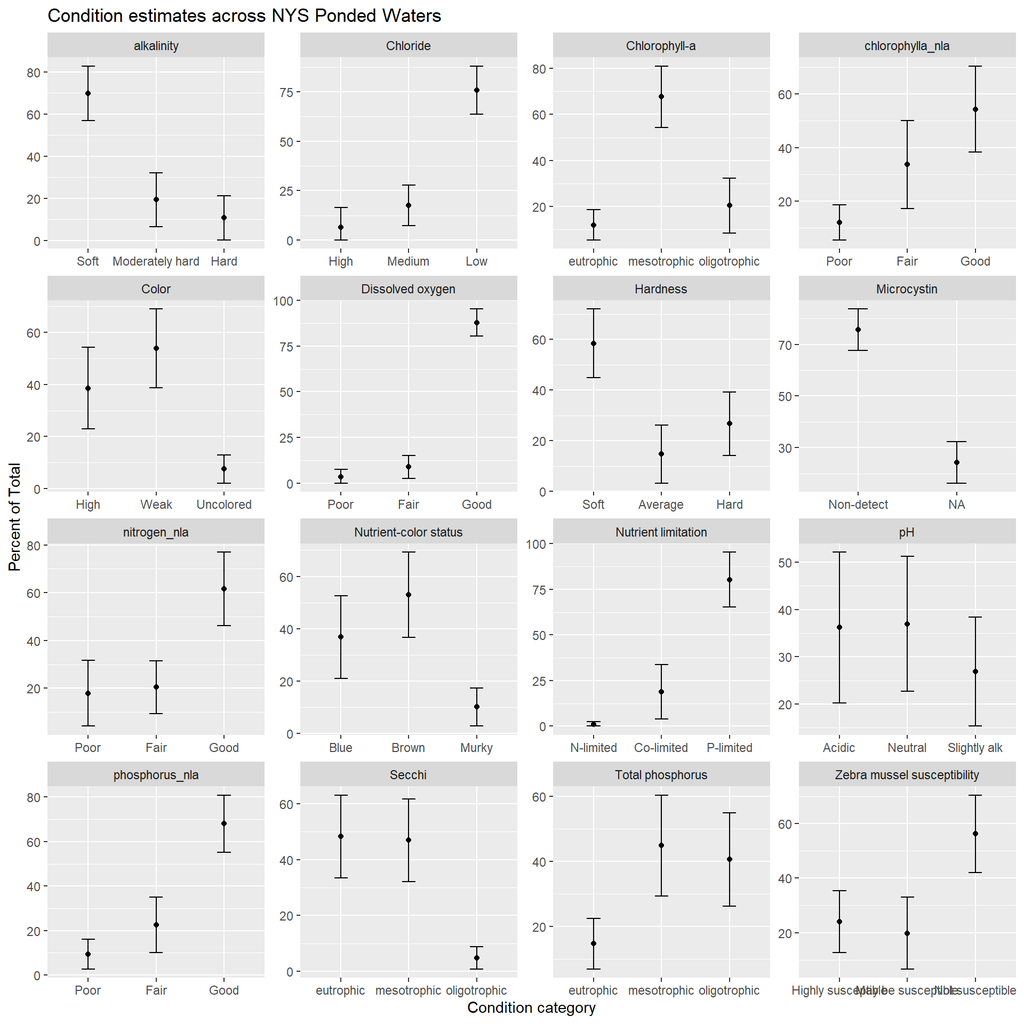

```r
ggplot(table,aes(x=Category,y=Estimate.P)) +
  geom_point()+
  geom_errorbar(aes(ymin=LCB95Pct.P,ymax=UCB95Pct.P),width=0.2)+
  theme(legend.position = "none")+
  facet_wrap(.~Indicator,scales = "free")+
  labs(title="Condition estimates across NYS Ponded Waters",y="Percent of Total",x="Condition category")
```

### Category bar plot

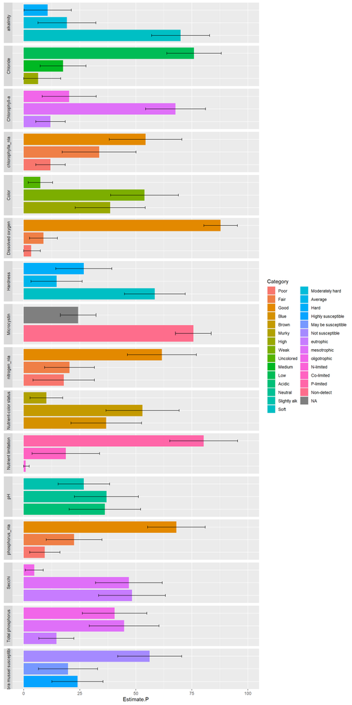

```r
# All
ggplot(table,aes(y=Estimate.P,x=Category,fill=Category))+
  geom_col()+
  ylim(0,100)+
  geom_errorbar(aes(ymin=LCB95Pct.P,ymax=UCB95Pct.P),width=0.2)+
  coord_flip()+
  theme(axis.title.y = element_blank(), axis.text.y = element_blank(),axis.ticks.y = element_blank())+
  facet_wrap(.~Indicator,scales = "free_y",ncol=1,strip.position = "left")
```

### Cumulative distribution function

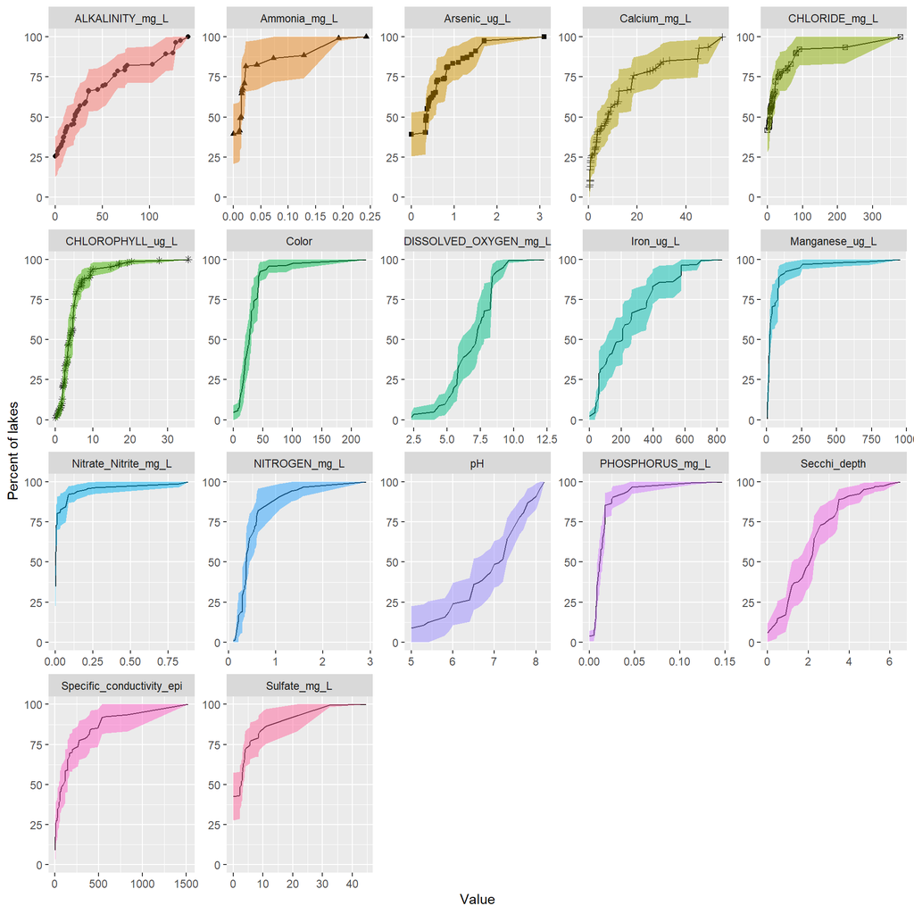

```r
#To plot a cumulative distribution function:
ggplot(analysis$CDF,aes(x=Value,y=Estimate.P,fill=Indicator,shape=Indicator,ymin=LCB95Pct.P,ymax=UCB95Pct.P))+
  geom_line()+
  geom_point()+
  geom_ribbon(alpha=0.5)+
  ylim(0,100)+
  facet_wrap(.~Indicator, scales="free")+
  guides(fill=FALSE,shape=FALSE)+
  labs(y="Percent of lakes")
```

## Comparisons

Compare with NLA, Northern Appalachian and New Hampshire.

### Category dot plot

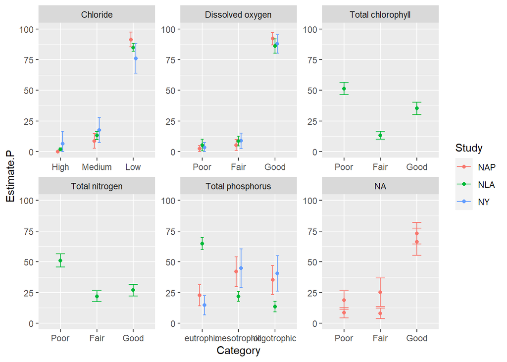

```r
#can't get NY trophic category to work
# cats <- rbind(ny.cat,nh.cat,nla.cat,nap.cat)
cats <- rbind(ny.cat,nla.cat,nap.cat)

ggplot(cats,aes(x=Category,y=Estimate.P,color=Study))+
  geom_point(position=position_dodge(width=0.2))+
  ylim(0,100)+
  geom_errorbar(aes(ymin=LCB95Pct.P, ymax=UCB95Pct.P), width=.25, position=position_dodge(width=0.2))+
  facet_wrap(.~Indicator, scales="free")
```

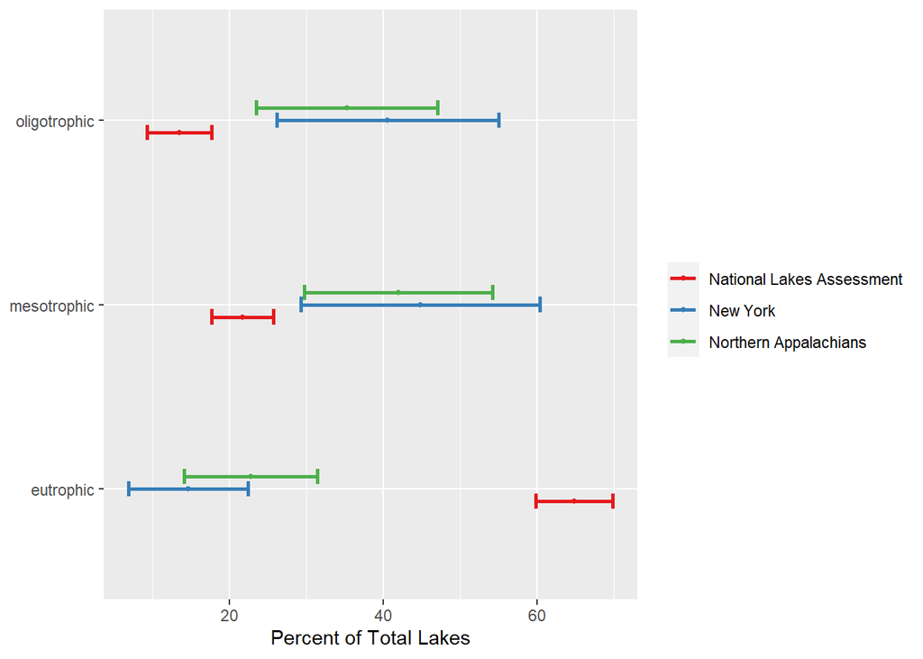

```r
trophic<-cats %>%
  filter(Indicator=="Total phosphorus") %>%
  mutate(Category=tolower(Category),
         Study=ifelse(Study=="NY","New York",Study),
         Study=ifelse(Study=="NLA","National Lakes Assessment",Study),
         Study=ifelse(Study=="NAP","Northern Appalachians",Study))
ggplot(trophic,aes(y=Category,x=Estimate.P,color=Study))+
  geom_point(position=position_dodge(width=0.2),size=1)+
  theme(axis.title.y=element_blank())+
  # theme(legend.position="bottom")+
  theme(legend.title=element_blank())+
  scale_colour_brewer(type="seq",palette="Set1")+
  xlab("Percent of Total Lakes")+
  geom_errorbar(aes(xmin=LCB95Pct.P, xmax=UCB95Pct.P), width=.25, position=position_dodge(width=0.2),size=1)
```

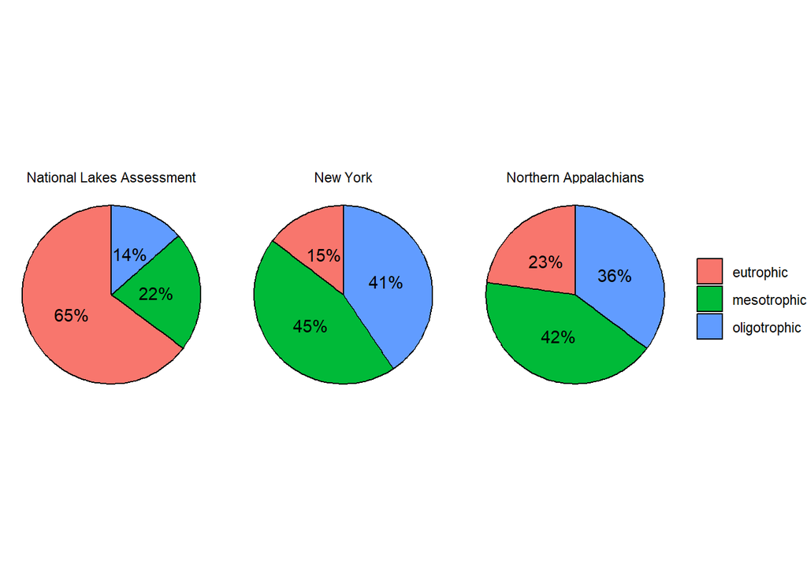

```r
ggplot(trophic,aes(x = "", y = Estimate.P, fill = Category))+
  geom_col(color = "black") +
  scale_colour_brewer(type="seq",palette="Set1")+
  geom_text(aes(label = paste(ceiling(Estimate.P),"%",sep="")),
            position = position_stack(vjust = 0.5)) +
  coord_polar(theta = "y")+
  theme_void()+
  theme(legend.title=element_blank())+
  facet_wrap(vars(Study))
```

### Cumulative distribution function

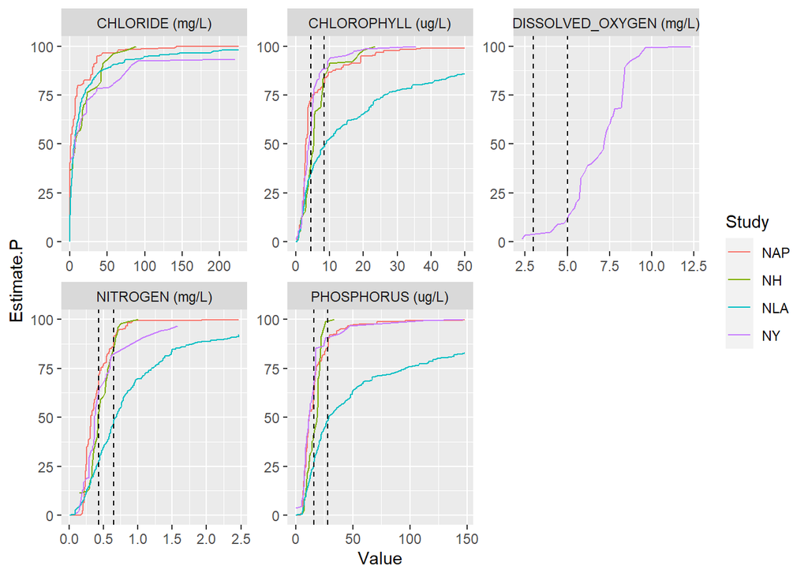

```r
ggplot(all,aes(x=Value,y=Estimate.P,color=Study,shape=Study))+
  geom_line()+
  ylim(0,100)+
  geom_vline(data=table,aes(xintercept=Low),linetype="dashed")+
  geom_vline(data=table,aes(xintercept=High),linetype="dashed")+
  facet_wrap(.~Indicator, scales="free")
```